# Segmentation des clients. Comprendre les différents types d'utilisateurs.

### Mise en œuvre d'un outil de segmentation qui regroupe les clients de profil similaire.

### Objectifs

- Développer un algorithme de segmentation pour aider les l’équipe e-commerce à mieux communiquer avec les clients.
- Proposer un contrat de maintenance basé sur une analyse de la stabilité des segments au cours du temps.

### Plan d'action

- Compréhension de la problématique métier.
- Description du jeu de données
- Transformation du jeu de données.
- Analyse RFM.
- Mise en place des algorithmes.
- Choix de la meilleure méthode.
- Analyse de la stabilité.

Ci-dessous la table des matières du présent notebook :

- 1. Compréhension de la problématique métier
- 2. Description du jeu de données
  - Données source
  - Analyse de forme
  - Analyse de fond
    - Variables quantitatives
    - Variables qualitatives
  - Analyse exploratoire

## 1. Compréhension de la problématique métier.

**Enjeux**

La société de vente en ligne **OLIST** souhaite fournir à ses employés un **outil de segmentation des clients** qu’ils pourront utiliser au quotidien pour leurs campagnes de communication.

Afin de bien segmenter les clients, il faut **comprendre les différents types d’utilisateurs** grâce à leur comportement et à leurs données personnelles. Ces informations ont été fournies par la société OLIST (base de données datant de janvier 2017 et comportant des informations sur :

- l’historique de commandes,
- les produits achetés,
- les commentaires de satisfaction
- la localisation des clients).

Il s'agit donc d'utiliser des **méthodes non supervisées**.

**Objectifs**

1. Regrouper des clients de profils similaires
2. Fournir une description actionable de la segmentation proposée et de sa logique sous-jacente.
3. Faire une proposition de contrat de maintenance basée sur une analyse de la stabilité future des segments.

## 2. Description du jeu de données

```python
from my_functions import *

%reload_ext autoreload
pd.options.display.float_format = '{:.3f}'.format
```

### Données source

Commençons par afficher les données source.

```python
# Liste de fichiers à notre disposition
print('Fichiers fournis :')
print(os.listdir(CSV_PATH))
```

```
Fichiers fournis :
['olist_order_items_dataset.csv', 'olist_orders_dataset.csv', 'olist_sellers_dataset.csv', 'olist_geolocation_dataset.csv', 'olist_customers_dataset.csv', 'olist_products_dataset.csv', 'olist_order_payments_dataset.csv', 'olist_order_reviews_dataset.csv', 'product_category_name_translation.csv']
```

Nous avons à notre disposition 9 fichiers sous format csv. Chargeons-les :

```python
# téléchargement des fichiers

clients = pd.read_csv(CSV_PATH + 'olist_customers_dataset.csv',
                      sep=',', encoding="utf-8", parse_dates=True)
cmd = pd.read_csv(CSV_PATH + 'olist_orders_dataset.csv',
                  sep=',', encoding="utf-8", parse_dates=True)
cmd_items = pd.read_csv(CSV_PATH + 'olist_order_items_dataset.csv',
                        sep=',', encoding="utf-8", parse_dates=True)
cmd_paiement = pd.read_csv(CSV_PATH + 'olist_order_payments_dataset.csv',
                           sep=',', encoding="utf-8", parse_dates=True)
produits = pd.read_csv(CSV_PATH + 'olist_products_dataset.csv',
                       sep=',', encoding="utf-8", parse_dates=True)
traduction = pd.read_csv(CSV_PATH + 'product_category_name_translation.csv',
                         sep=',', encoding="utf-8", parse_dates=True)
cmd_review = pd.read_csv(CSV_PATH + 'olist_order_reviews_dataset.csv',
                         sep=',', encoding="utf-8", parse_dates=True)
geolocation = pd.read_csv(CSV_PATH + 'olist_geolocation_dataset.csv',
                          sep=',', encoding="utf-8", parse_dates=True)
vendeurs = pd.read_csv(CSV_PATH + 'olist_sellers_dataset.csv',
                       sep=',', encoding="utf-8", parse_dates=True)
```

Vérifions les dimensions de chaque fichier :

```python
dataframes = {'clients': clients, 'cmd': cmd, 'cmd_items': cmd_items, 'cmd_paiement': cmd_paiement, 'produits': produits,
              'cmd_review': cmd_review, 'traduction': traduction, 'geolocation': geolocation, 'vendeurs': vendeurs}
for cle, valeur in dataframes.items():
    print("Taille du dataset \"", cle, "\" ===>", valeur.shape)
```

```
Taille du dataset " clients " ===> (99441, 5)
Taille du dataset " cmd " ===> (99441, 8)
Taille du dataset " cmd_items " ===> (112650, 7)
Taille du dataset " cmd_paiement " ===> (103886, 5)
Taille du dataset " produits " ===> (32951, 9)
Taille du dataset " cmd_review " ===> (99224, 7)
Taille du dataset " traduction " ===> (71, 2)
Taille du dataset " geolocation " ===> (1000163, 5)
Taille du dataset " vendeurs " ===> (3095, 4)
```

Les fichiers ne sont pas volumineux (sauf le fichier "geolocation" qui comprend 1000163 lignes), nous observons un nombre peu élevé de colonnes.

Voyons s'il est possible de procéder au merge de données. Nous allons regrouper les données par thématique et ensuite afficher les premières lignes :

- données sur le client
- données sur la commande
- données sur le produit

**1. Fiches client**

```python
clients.head()
```

|  | customer_id | customer_unique_id | customer_zip_code_prefix | customer_city | customer_state |
| --- | --- | --- | --- | --- | --- |
| 0 | 06b8999e2fba1a1fbc88172c00ba8bc7 | 861eff4711a542e4b93843c6dd7febb0 | 14409 | franca | SP |
| 1 | 18955e83d337fd6b2def6b18a428ac77 | 290c77bc529b7ac935b93aa66c333dc3 | 9790 | sao bernardo do campo | SP |
| 2 | 4e7b3e00288586ebd08712fdd0374a03 | 060e732b5b29e8181a18229c7b0b2b5e | 1151 | sao paulo | SP |
| 3 | b2b6027bc5c5109e529d4dc6358b12c3 | 259dac757896d24d7702b9acbbff3f3c | 8775 | mogi das cruzes | SP |
| 4 | 4f2d8ab171c80ec8364f7c12e35b23ad | 345ecd01c38d18a9036ed96c73b8d066 | 13056 | campinas | SP |

```python
geolocation.head()
```

|  | geolocation_zip_code_prefix | geolocation_lat | geolocation_lng | geolocation_city | geolocation_state |
| --- | --- | --- | --- | --- | --- |
| 0 | 1037 | -23.546 | -46.639 | sao paulo | SP |
| 1 | 1046 | -23.546 | -46.645 | sao paulo | SP |
| 2 | 1046 | -23.546 | -46.643 | sao paulo | SP |
| 3 | 1041 | -23.544 | -46.639 | sao paulo | SP |
| 4 | 1035 | -23.542 | -46.642 | sao paulo | SP |

```python
vendeurs.head()
```

|  | seller_id | seller_zip_code_prefix | seller_city | seller_state |
| --- | --- | --- | --- | --- |
| 0 | 3442f8959a84dea7ee197c632cb2df15 | 13023 | campinas | SP |
| 1 | d1b65fc7debc3361ea86b5f14c68d2e2 | 13844 | mogi guacu | SP |
| 2 | ce3ad9de960102d0677a81f5d0bb7b2d | 20031 | rio de janeiro | RJ |
| 3 | c0f3eea2e14555b6faeea3dd58c1b1c3 | 4195 | sao paulo | SP |
| 4 | 51a04a8a6bdcb23deccc82b0b80742cf | 12914 | braganca paulista | SP |

**Conclusion**

Nous remarquons l'existence d'informations en commun, notamment celles concernant le `state` ou `city` d'un client. Il s'agit d'une information redondante. Pas de fusion pour ces tables.

**2. Fiches commande**

```python
cmd.head()
```

|  | order_id | customer_id | order_status | order_purchase_timestamp | order_approved_at | order_delivered_carrier_date | order_delivered_customer_date | order_estimated_delivery_date |
| --- | --- | --- | --- | --- | --- | --- | --- | --- |
| 0 | e481f51cbdc54678b7cc49136f2d6af7 | 9ef432eb6251297304e76186b10a928d | delivered | 2017-10-02 10:56:33 | 2017-10-02 11:07:15 | 2017-10-04 19:55:00 | 2017-10-10 21:25:13 | 2017-10-18 00:00:00 |
| 1 | 53cdb2fc8bc7dce0b6741e2150273451 | b0830fb4747a6c6d20dea0b8c802d7ef | delivered | 2018-07-24 20:41:37 | 2018-07-26 03:24:27 | 2018-07-26 14:31:00 | 2018-08-07 15:27:45 | 2018-08-13 00:00:00 |
| 2 | 47770eb9100c2d0c44946d9cf07ec65d | 41ce2a54c0b03bf3443c3d931a367089 | delivered | 2018-08-08 08:38:49 | 2018-08-08 08:55:23 | 2018-08-08 13:50:00 | 2018-08-17 18:06:29 | 2018-09-04 00:00:00 |
| 3 | 949d5b44dbf5de918fe9c16f97b45f8a | f88197465ea7920adcdbec7375364d82 | delivered | 2017-11-18 19:28:06 | 2017-11-18 19:45:59 | 2017-11-22 13:39:59 | 2017-12-02 00:28:42 | 2017-12-15 00:00:00 |
| 4 | ad21c59c0840e6cb83a9ceb5573f8159 | 8ab97904e6daea8866dbdbc4fb7aad2c | delivered | 2018-02-13 21:18:39 | 2018-02-13 22:20:29 | 2018-02-14 19:46:34 | 2018-02-16 18:17:02 | 2018-02-26 00:00:00 |

```python
cmd_items.head()
```

|  | order_id | order_item_id | product_id | seller_id | shipping_limit_date | price | freight_value |
| --- | --- | --- | --- | --- | --- | --- | --- |
| 0 | 00010242fe8c5a6d1ba2dd792cb16214 | 1 | 4244733e06e7ecb4970a6e2683c13e61 | 48436dade18ac8b2bce089ec2a041202 | 2017-09-19 09:45:35 | 58.900 | 13.290 |
| 1 | 00018f77f2f0320c557190d7a144bdd3 | 1 | e5f2d52b802189ee658865ca93d83a8f | dd7ddc04e1b6c2c614352b383efe2d36 | 2017-05-03 11:05:13 | 239.900 | 19.930 |
| 2 | 000229ec398224ef6ca0657da4fc703e | 1 | c777355d18b72b67abbeef9df44fd0fd | 5b51032eddd242adc84c38acab88f23d | 2018-01-18 14:48:30 | 199.000 | 17.870 |
| 3 | 00024acbcdf0a6daa1e931b038114c75 | 1 | 7634da152a4610f1595efa32f14722fc | 9d7a1d34a5052409006425275ba1c2b4 | 2018-08-15 10:10:18 | 12.990 | 12.790 |
| 4 | 00042b26cf59d7ce69dfabb4e55b4fd9 | 1 | ac6c3623068f30de03045865e4e10089 | df560393f3a51e74553ab94004ba5c87 | 2017-02-13 13:57:51 | 199.900 | 18.140 |

```python
cmd_review.head()
```

|  | review_id | order_id | review_score | review_comment_title | review_comment_message | review_creation_date | review_answer_timestamp |
| --- | --- | --- | --- | --- | --- | --- | --- |
| 0 | 7bc2406110b926393aa56f80a40eba40 | 73fc7af87114b39712e6da79b0a377eb | 4 | NaN | NaN | 2018-01-18 00:00:00 | 2018-01-18 21:46:59 |
| 1 | 80e641a11e56f04c1ad469d5645fdfde | a548910a1c6147796b98fdf73dbeba33 | 5 | NaN | NaN | 2018-03-10 00:00:00 | 2018-03-11 03:05:13 |
| 2 | 228ce5500dc1d8e020d8d1322874b6f0 | f9e4b658b201a9f2ecdecbb34bed034b | 5 | NaN | NaN | 2018-02-17 00:00:00 | 2018-02-18 14:36:24 |
| 3 | e64fb393e7b32834bb789ff8bb30750e | 658677c97b385a9be170737859d3511b | 5 | NaN | Recebi bem antes do prazo estipulado. | 2017-04-21 00:00:00 | 2017-04-21 22:02:06 |
| 4 | f7c4243c7fe1938f181bec41a392bdeb | 8e6bfb81e283fa7e4f11123a3fb894f1 | 5 | NaN | Parabéns lojas lannister adorei comprar pela I... | 2018-03-01 00:00:00 | 2018-03-02 10:26:53 |

```python
cmd_paiement.head()
```

|  | order_id | payment_sequential | payment_type | payment_installments | payment_value |
| --- | --- | --- | --- | --- | --- |
| 0 | b81ef226f3fe1789b1e8b2acac839d17 | 1 | credit_card | 8 | 99.330 |
| 1 | a9810da82917af2d9aefd1278f1dcfa0 | 1 | credit_card | 1 | 24.390 |
| 2 | 25e8ea4e93396b6fa0d3dd708e76c1bd | 1 | credit_card | 1 | 65.710 |
| 3 | ba78997921bbcdc1373bb41e913ab953 | 1 | credit_card | 8 | 107.780 |
| 4 | 42fdf880ba16b47b59251dd489d4441a | 1 | credit_card | 2 | 128.450 |

**Conclusion**

Présence d'un ID en commun : `order_id`. Nous allons procéder à une fusion des tables, en gardant uniquement les features pertinentes :

```python
cmd_1 = cmd.merge(cmd_items, on='order_id')
cmd_2 = cmd_1.merge(cmd_paiement, on='order_id')
cmd_df = cmd_2.merge(cmd_review[['review_score', 'order_id']], on='order_id')
```

```python
cmd_df.info()
```

```
<class 'pandas.core.frame.DataFrame'>
Int64Index: 117329 entries, 0 to 117328
Data columns (total 19 columns):
 #   Column                         Non-Null Count   Dtype
---  ------                         --------------   -----
 0   order_id                       117329 non-null  object
 1   customer_id                    117329 non-null  object
 2   order_status                   117329 non-null  object
 3   order_purchase_timestamp       117329 non-null  object
 4   order_approved_at              117314 non-null  object
 5   order_delivered_carrier_date   116094 non-null  object
 6   order_delivered_customer_date  114858 non-null  object
 7   order_estimated_delivery_date  117329 non-null  object
 8   order_item_id                  117329 non-null  int64
 9   product_id                     117329 non-null  object
 10  seller_id                      117329 non-null  object
 11  shipping_limit_date            117329 non-null  object
 12  price                          117329 non-null  float64
 13  freight_value                  117329 non-null  float64
 14  payment_sequential             117329 non-null  int64
 15  payment_type                   117329 non-null  object
 16  payment_installments           117329 non-null  int64
 17  payment_value                  117329 non-null  float64
 18  review_score                   117329 non-null  int64
dtypes: float64(3), int64(4), object(12)
memory usage: 17.9+ MB
```

**3. Fiches produit**

```python
produits.head()
```

|  | product_id | product_category_name | product_name_lenght | product_description_lenght | product_photos_qty | product_weight_g | product_length_cm | product_height_cm | product_width_cm |
| --- | --- | --- | --- | --- | --- | --- | --- | --- | --- |
| 0 | 1e9e8ef04dbcff4541ed26657ea517e5 | perfumaria | 40.000 | 287.000 | 1.000 | 225.000 | 16.000 | 10.000 | 14.000 |
| 1 | 3aa071139cb16b67ca9e5dea641aaa2f | artes | 44.000 | 276.000 | 1.000 | 1000.000 | 30.000 | 18.000 | 20.000 |
| 2 | 96bd76ec8810374ed1b65e291975717f | esporte_lazer | 46.000 | 250.000 | 1.000 | 154.000 | 18.000 | 9.000 | 15.000 |
| 3 | cef67bcfe19066a932b7673e239eb23d | bebes | 27.000 | 261.000 | 1.000 | 371.000 | 26.000 | 4.000 | 26.000 |
| 4 | 9dc1a7de274444849c219cff195d0b71 | utilidades_domesticas | 37.000 | 402.000 | 4.000 | 625.000 | 20.000 | 17.000 | 13.000 |

```python
traduction.head()
```

|  | product_category_name | product_category_name_english |
| --- | --- | --- |
| 0 | beleza_saude | health_beauty |
| 1 | informatica_acessorios | computers_accessories |
| 2 | automotivo | auto |
| 3 | cama_mesa_banho | bed_bath_table |
| 4 | moveis_decoracao | furniture_decor |

Nous remarquons la présence d'une même variable `product_category_name` dans les fichiers ci-dessus. Il serait plus intéressant de récupérer les noms anglais de produits achetés :

```python
# remplacement noms de produits portugais par traduction anglaise
english = traduction.merge(
    produits[['product_id', 'product_category_name']], on='product_category_name')
english.drop(english[['product_category_name']], axis=1, inplace=True)
english.rename(
    {'product_category_name_english': 'product_category_name'}, axis=1, inplace=True)
```

```python
english.info()
```

```
<class 'pandas.core.frame.DataFrame'>
Int64Index: 32328 entries, 0 to 32327
Data columns (total 2 columns):
 #   Column                 Non-Null Count  Dtype
---  ------                 --------------  -----
 0   product_category_name  32328 non-null  object
 1   product_id             32328 non-null  object
dtypes: object(2)
memory usage: 757.7+ KB
```

**Jeu de données final**

Nous allons à présent préparer un seul fichier regroupant les datasets aggrégés : `commande + client + produits`:

```python
# données sur la commande + données traduites
df1 = cmd_df.merge(english, on='product_id')
# données sur la commande + données clients
df = df1.merge(clients, on='customer_id')
```

```python
df.info()
```

```
<class 'pandas.core.frame.DataFrame'>
Int64Index: 115609 entries, 0 to 115608
Data columns (total 24 columns):
 #   Column                         Non-Null Count   Dtype
---  ------                         --------------   -----
 0   order_id                       115609 non-null  object
 1   customer_id                    115609 non-null  object
 2   order_status                   115609 non-null  object
 3   order_purchase_timestamp       115609 non-null  object
 4   order_approved_at              115595 non-null  object
 5   order_delivered_carrier_date   114414 non-null  object
 6   order_delivered_customer_date  113209 non-null  object
 7   order_estimated_delivery_date  115609 non-null  object
 8   order_item_id                  115609 non-null  int64
 9   product_id                     115609 non-null  object
```

[output cut: 16 more lines]

## Analyse de forme

**Dimensions du jeu de données**

```python
print('Data shape: ', df.shape)
df.head()
```

```
Data shape:  (115609, 24)
```

|  | order_id | customer_id | order_status | order_purchase_timestamp | order_approved_at | order_delivered_carrier_date | order_delivered_customer_date | order_estimated_delivery_date | order_item_id | product_id | ... | payment_sequential | payment_type | payment_installments | payment_value | review_score | product_category_name | customer_unique_id | customer_zip_code_prefix | customer_city | customer_state |
| --- | --- | --- | --- | --- | --- | --- | --- | --- | --- | --- | --- | --- | --- | --- | --- | --- | --- | --- | --- | --- | --- |
| 0 | e481f51cbdc54678b7cc49136f2d6af7 | 9ef432eb6251297304e76186b10a928d | delivered | 2017-10-02 10:56:33 | 2017-10-02 11:07:15 | 2017-10-04 19:55:00 | 2017-10-10 21:25:13 | 2017-10-18 00:00:00 | 1 | 87285b34884572647811a353c7ac498a | ... | 1 | credit_card | 1 | 18.120 | 4 | housewares | 7c396fd4830fd04220f754e42b4e5bff | 3149 | sao paulo | SP |
| 1 | e481f51cbdc54678b7cc49136f2d6af7 | 9ef432eb6251297304e76186b10a928d | delivered | 2017-10-02 10:56:33 | 2017-10-02 11:07:15 | 2017-10-04 19:55:00 | 2017-10-10 21:25:13 | 2017-10-18 00:00:00 | 1 | 87285b34884572647811a353c7ac498a | ... | 3 | voucher | 1 | 2.000 | 4 | housewares | 7c396fd4830fd04220f754e42b4e5bff | 3149 | sao paulo | SP |
| 2 | e481f51cbdc54678b7cc49136f2d6af7 | 9ef432eb6251297304e76186b10a928d | delivered | 2017-10-02 10:56:33 | 2017-10-02 11:07:15 | 2017-10-04 19:55:00 | 2017-10-10 21:25:13 | 2017-10-18 00:00:00 | 1 | 87285b34884572647811a353c7ac498a | ... | 2 | voucher | 1 | 18.590 | 4 | housewares | 7c396fd4830fd04220f754e42b4e5bff | 3149 | sao paulo | SP |
| 3 | 128e10d95713541c87cd1a2e48201934 | a20e8105f23924cd00833fd87daa0831 | delivered | 2017-08-15 18:29:31 | 2017-08-15 20:05:16 | 2017-08-17 15:28:33 | 2017-08-18 14:44:43 | 2017-08-28 00:00:00 | 1 | 87285b34884572647811a353c7ac498a | ... | 1 | credit_card | 3 | 37.770 | 4 | housewares | 3a51803cc0d012c3b5dc8b7528cb05f7 | 3366 | sao paulo | SP |
| 4 | 0e7e841ddf8f8f2de2bad69267ecfbcf | 26c7ac168e1433912a51b924fbd34d34 | delivered | 2017-08-02 18:24:47 | 2017-08-02 18:43:15 | 2017-08-04 17:35:43 | 2017-08-07 18:30:01 | 2017-08-15 00:00:00 | 1 | 87285b34884572647811a353c7ac498a | ... | 1 | credit_card | 1 | 37.770 | 5 | housewares | ef0996a1a279c26e7ecbd737be23d235 | 2290 | sao paulo | SP |

5 rows × 24 columns

#### Types de variables

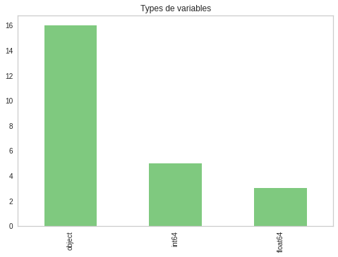

```python
df.dtypes.value_counts().plot.bar(title='Types de variables', cmap="Accent")
plt.grid()
plt.show()
```

La majorité des variables sont donc de type `object`. Regardons-les de plus près.

#### Variables catégorielles

```python
df.select_dtypes('object').apply(pd.Series.nunique, axis=0)
```

```
order_id                         96516
customer_id                      96516
order_status                         7
order_purchase_timestamp         95989
order_approved_at                88332
order_delivered_carrier_date     79241
order_delivered_customer_date    93702
order_estimated_delivery_date      449
product_id                       32171
seller_id                         3028
shipping_limit_date              91386
payment_type                         4
product_category_name               71
customer_unique_id               93396
customer_city                     4093
customer_state                      27
dtype: int64
```

Un aperçu rapide du contenu :

```python
df.product_id.unique()
```

```
array(['87285b34884572647811a353c7ac498a',
       '595fac2a385ac33a80bd5114aec74eb8',
       '0e2d365a247d105fefc31b17ab8706d9', ...,
       '3d2c44374ee42b3003a470f3e937a2ea',
       'ac35486adb7b02598c182c2ff2e05254',
       '006619bbed68b000c8ba3f8725d5409e'], dtype=object)
```

```python
df.customer_id.unique()
```

```
array(['9ef432eb6251297304e76186b10a928d',
       'a20e8105f23924cd00833fd87daa0831',
       '26c7ac168e1433912a51b924fbd34d34', ...,
       'a2f7428f0cafbc8e59f20e1444b67315',
       '39bd1228ee8140590ac3aca26f2dfe00',
       'edb027a75a1449115f6b43211ae02a24'], dtype=object)
```

```python
df.order_approved_at.unique()
```

```
array(['2017-10-02 11:07:15', '2017-08-15 20:05:16',
       '2017-08-02 18:43:15', ..., '2017-08-10 21:35:26',
       '2017-03-09 09:54:05', '2018-03-09 11:20:28'], dtype=object)
```

```python
df.order_purchase_timestamp.unique()
```

```
array(['2017-10-02 10:56:33', '2017-08-15 18:29:31',
       '2017-08-02 18:24:47', ..., '2017-12-20 09:52:41',
       '2017-03-09 09:54:05', '2018-03-08 20:57:30'], dtype=object)
```

```python
df.shipping_limit_date.unique()
```

```
array(['2017-10-06 11:07:15', '2017-08-21 20:05:16',
       '2017-08-08 18:37:31', ..., '2017-08-17 21:35:26',
       '2017-03-15 09:54:05', '2018-03-15 10:55:42'], dtype=object)
```

Plusieurs variables semblent être de nature numérique malgré tout : celles étant des ID et celles étant des dates. Nous allons convertir en variables numériques les features contenant les dates.

**Conversion de variables contenant une date au format numérique**

```python
def conversion_date(df, ft):
    df[ft] = pd.to_datetime(df[ft])
```

```python
conversion_date(df, 'shipping_limit_date')
conversion_date(df, 'order_approved_at')
conversion_date(df, 'order_purchase_timestamp')
conversion_date(df, 'order_delivered_carrier_date')
conversion_date(df, 'order_delivered_customer_date')
conversion_date(df, 'order_estimated_delivery_date')
```

#### Variables numériques

```python
df.select_dtypes('int').apply(pd.Series.nunique, axis=0)
```

```
order_item_id                  21
payment_sequential             29
payment_installments           24
review_score                    5
customer_zip_code_prefix    14907
dtype: int64
```

```python
df.select_dtypes('float').apply(pd.Series.nunique, axis=0)
```

```
price             5879
freight_value     6954
payment_value    28657
dtype: int64
```

```python
df.select_dtypes('datetime').apply(pd.Series.nunique, axis=0)
```

```
order_purchase_timestamp         95989
order_approved_at                88332
order_delivered_carrier_date     79241
order_delivered_customer_date    93702
order_estimated_delivery_date      449
shipping_limit_date              91386
dtype: int64
```

#### Modalités

```python
for key, value in df.select_dtypes('object').iteritems():
    print(f'{key :-<50} {len(df[key].unique())}')
```

```
order_id------------------------------------------ 96516
customer_id--------------------------------------- 96516
order_status-------------------------------------- 7
product_id---------------------------------------- 32171
seller_id----------------------------------------- 3028
payment_type-------------------------------------- 4
product_category_name----------------------------- 71
customer_unique_id-------------------------------- 93396
customer_city------------------------------------- 4093
customer_state------------------------------------ 27
```

```python
for key, value in df.select_dtypes(exclude='object').iteritems():
    print(f'{key :-<50} {len(df[key].unique())}')
```

```
order_purchase_timestamp-------------------------- 95989
order_approved_at--------------------------------- 88333
order_delivered_carrier_date---------------------- 79242
order_delivered_customer_date--------------------- 93703
order_estimated_delivery_date--------------------- 449
order_item_id------------------------------------- 21
shipping_limit_date------------------------------- 91386
price--------------------------------------------- 5879
freight_value------------------------------------- 6954
payment_sequential-------------------------------- 29
payment_installments------------------------------ 24
payment_value------------------------------------- 28657
review_score-------------------------------------- 5
customer_zip_code_prefix-------------------------- 14907
```

Certaines variables se caractérisent par un nombre de modalités très restreint. Il s'agit de caractéristiques suivantes :

- `review_score` => Note finale attribuée
- `payment_type` => Types de paiement
- `order_status` => Status de la commande

```python
df.review_score.unique()
```

```
array([4, 5, 3, 1, 2])
```

```python
df.payment_type.unique()
```

```
array(['credit_card', 'voucher', 'boleto', 'debit_card'], dtype=object)
```

```python
df. order_status.unique()
```

```
array(['delivered', 'shipped', 'invoiced', 'canceled', 'processing',
       'unavailable', 'approved'], dtype=object)
```

**Valeurs manquantes**

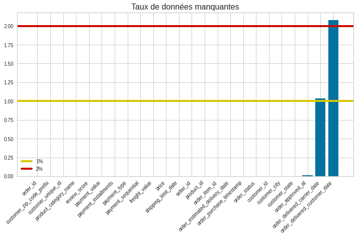

```python
taux_nan = df.isna().sum()*100/df.shape[0]
fig = plt.figure(figsize=(12, 6))
plt.xticks(rotation=45,
           horizontalalignment='right',
           fontweight='light',
           fontsize='small')

plt.bar(x=taux_nan.sort_values().index,
        height=taux_nan.sort_values().values)

plt.axhline(y=1, color='y', linestyle='-', linewidth='4', label='1%')
plt.axhline(y=2, color='r', linestyle='-', linewidth='4', label='2%')
plt.title("Taux de données manquantes", fontsize=16)
plt.legend()
plt.show()
```

Très peu de valeurs manquantes ! Vérifions de quelles variables il s'agit :

```python
df.isnull().sum()
```

```
order_id                            0
customer_id                         0
order_status                        0
order_purchase_timestamp            0
order_approved_at                  14
order_delivered_carrier_date     1195
order_delivered_customer_date    2400
order_estimated_delivery_date       0
order_item_id                       0
product_id                          0
seller_id                           0
shipping_limit_date                 0
price                               0
freight_value                       0
payment_sequential                  0
payment_type                        0
payment_installments                0
payment_value                       0
review_score                        0
product_category_name               0
customer_unique_id                  0
customer_zip_code_prefix            0
customer_city                       0
customer_state                      0
dtype: int64
```

Il s'agit de variables étant des dates. Sur 115609 observations, nous avons :

- 14 NaN pour `order_approved_at`
- 1195 NaN pour `order_delivered_carrier_date`
- 2400 NaN pour `order_delivered_customer_date`

Réfléchissons comment récupérer ces informations.

Etant donné le préfixe `order_delivered_*`, les données manquantes sembleraient concerner le status de la livraison de commande. Croisons cette donnée avec la feature `order_status` :

```python
df[df['order_delivered_customer_date'].isnull()]['order_status'].value_counts()
```

```
shipped        1138
canceled        529
invoiced        358
processing      357
delivered         8
unavailable       7
approved          3
Name: order_status, dtype: int64
```

Les données manquantes (au nombre de 2400 items) se positionnent principalement au niveau du status `shipped` et `canceled`. Regardons les chiffres du côté du status de commande :

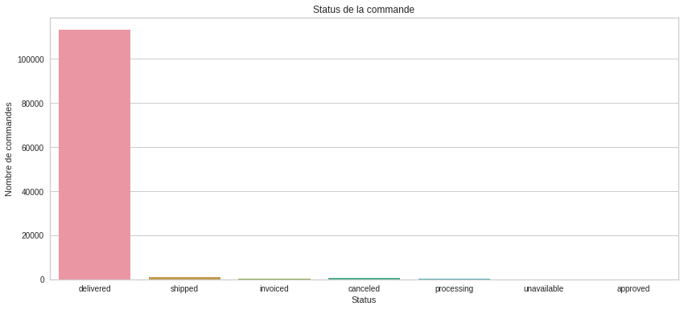

```python
plt.figure(figsize=(14, 6))
sns.countplot(x='order_status', data=df)
plt.title('Status de la commande')
plt.xlabel('Status')
plt.ylabel('Nombre de commandes')
plt.show()
```

```python
df.order_status.value_counts(normalize=True)
```

```
delivered     0.979
shipped       0.010
canceled      0.005
invoiced      0.003
processing    0.003
unavailable   0.000
approved      0.000
Name: order_status, dtype: float64
```

Etant donné que pour la suite de notre analyse nous allons nous intéresser à un cycle complet de la commande, (c'est-à-dire les commandes effectuées et délivrées), les autres status de commande nous semblent inutiles. Par conséquent nous allons procéder à leur suppression.

```python
df = df[df['order_status'] == 'delivered']
```

Regardons à nouveau les valeurs manquantes :

```python
df.isnull().sum()
```

```
order_id                          0
customer_id                       0
order_status                      0
order_purchase_timestamp          0
order_approved_at                14
order_delivered_carrier_date      2
order_delivered_customer_date     8
order_estimated_delivery_date     0
order_item_id                     0
product_id                        0
seller_id                         0
shipping_limit_date               0
price                             0
freight_value                     0
payment_sequential                0
payment_type                      0
payment_installments              0
payment_value                     0
review_score                      0
product_category_name             0
customer_unique_id                0
customer_zip_code_prefix          0
customer_city                     0
customer_state                    0
dtype: int64
```

Nous allons supprimer les NaN restants :

```python
df = df.dropna()
```

**Doublons**

Passons à présent à l'identification et suppression des doublons :

```python
df.duplicated().sum()
```

```
405
```

```python
df.drop_duplicates(inplace=True)
```

```python
df.shape
```

```
(112782, 24)
```

## Analyse de fond

Nous allons effectuer une analyse de distributions de features présentes dans le jeu de données. Dans un premier temps les variables quantitatives, ensuite les qualitatives.

### Variables quantitatives

**Float**

```python
var_float = df.select_dtypes('float')
var_float.describe()
```

|  | price | freight_value | payment_value |
| --- | --- | --- | --- |
| count | 112782.000 | 112782.000 | 112782.000 |
| mean | 119.961 | 20.012 | 171.665 |
| std | 181.353 | 15.726 | 264.514 |
| min | 0.850 | 0.000 | 0.000 |
| 25% | 39.900 | 13.080 | 60.870 |
| 50% | 74.900 | 16.320 | 108.000 |
| 75% | 133.000 | 21.190 | 189.220 |
| max | 6735.000 | 409.680 | 13664.080 |

Il s'agit principalement de données autour du prix :

- du produit acheté
- de la charge du produit (poids)
- du prix final payé

La valeur minimale de la feature `payment_value` égale `0`, cette donnée est à surveiller. Sinon pas d'anomalies observées.

Vérifions comment évoluent les prix.

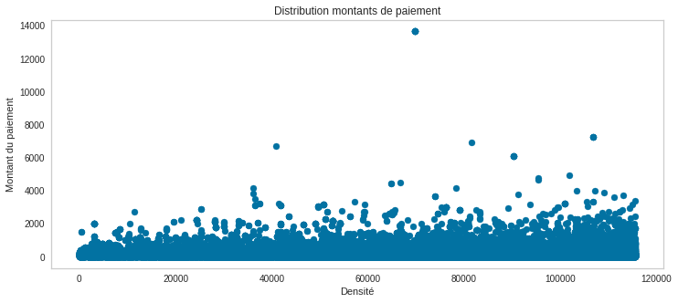

```python
plt.figure(figsize=(12, 5))
plt.scatter(df.index, df['payment_value'])

plt.ylabel("Montant du paiement")
plt.xlabel('Densité')
plt.title("Distribution montants de paiement")
plt.grid()
plt.show()
```

- Nous retrouvons la valeur maximale de `13664.080`.
- 5 prix payés dépassent le montant de 6000 réis brésiliens.
- La plupart des prix payés se situent en dessous des 1000 réis brésiliens.

**Integer**

```python
var_int = df.select_dtypes('int')
var_int.describe()
```

|  | order_item_id | payment_sequential | payment_installments | review_score | customer_zip_code_prefix |
| --- | --- | --- | --- | --- | --- |
| count | 112782.000 | 112782.000 | 112782.000 | 112782.000 | 112782.000 |
| mean | 1.195 | 1.090 | 2.942 | 4.082 | 35087.651 |
| std | 0.686 | 0.684 | 2.778 | 1.346 | 29865.084 |
| min | 1.000 | 1.000 | 0.000 | 1.000 | 1003.000 |
| 25% | 1.000 | 1.000 | 1.000 | 4.000 | 11310.000 |
| 50% | 1.000 | 1.000 | 2.000 | 5.000 | 24315.000 |
| 75% | 1.000 | 1.000 | 4.000 | 5.000 | 58876.250 |
| max | 21.000 | 26.000 | 24.000 | 5.000 | 99980.000 |

La valeur minimale de la feature `payment_installements` peut indiquer qu'il s'agit d'un achat à crédit. Ceci est probablement en rapport avec la variable `payment_value` mentionnée plus haut. Un achat à crédit est donc à l'origine des valeurs de prix nulles.

**Paiement échelonné**

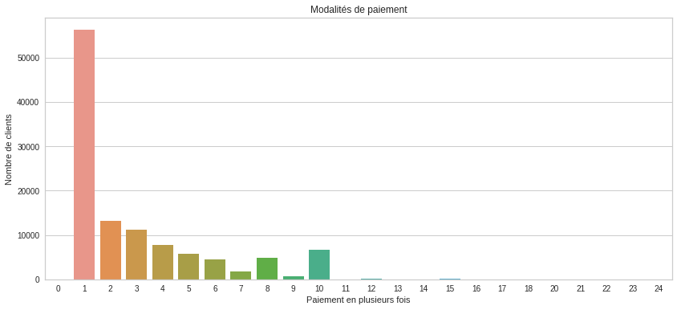

```python
plt.figure(figsize=(14, 6))
sns.countplot(x='payment_installments', data=df)
plt.title('Modalités de paiement')
plt.xlabel('Paiement en plusieurs fois')
plt.ylabel('Nombre de clients')
plt.show()
```

```python
#df = df.loc[df['payment_installments'].isin([1,2,3,4,5,6,7,8,9,10,12,15])]
```

**Note attribuée**

Il est intéressant de faire focus sur la feature `review_score`. Regardons comment sont répartis les avis des utilisateurs :

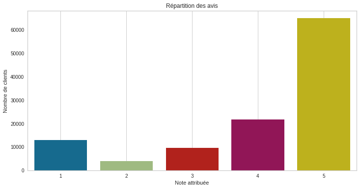

```python
plt.figure(figsize=(12, 6))
sns.countplot(x='review_score', data=df)

plt.title('Répartition des avis')
plt.ylabel('Nombre de clients')
plt.xlabel('Note attribuée')
plt.grid()
plt.show()
```

- La grande majorité des clients ont émis un avis très positif (plus de 60 000).
- Les moins nombreux sont les clients qui ont attribué la note 2 (moins de 5 000).
- Pas mal d'utilisateurs du service n'ont pas été satisfaits du tout (environ 15 000).

### Variables qualitatives

```python
var_cat = df.select_dtypes('object')
var_cat.describe().T
```

|  | count | unique | top | freq |
| --- | --- | --- | --- | --- |
| order_id | 112782 | 94466 | 895ab968e7bb0d5659d16cd74cd1650c | 63 |
| customer_id | 112782 | 94466 | 270c23a11d024a44c896d1894b261a83 | 63 |
| order_status | 112782 | 1 | delivered | 112782 |
| product_id | 112782 | 31475 | aca2eb7d00ea1a7b8ebd4e68314663af | 526 |
| seller_id | 112782 | 2907 | 4a3ca9315b744ce9f8e9374361493884 | 2086 |
| payment_type | 112782 | 4 | credit_card | 83244 |
| product_category_name | 112782 | 71 | bed_bath_table | 11594 |
| customer_unique_id | 112782 | 91460 | 9a736b248f67d166d2fbb006bcb877c3 | 75 |
| customer_city | 112782 | 4071 | sao paulo | 17792 |
| customer_state | 112782 | 27 | SP | 47628 |

La moitié des variables constituent des ID. Vérifions si des modalités anormales sont présentes au sein des variables n'étant pas un ID :

```python
df_object = df[['order_status', 'payment_type',
                'product_category_name', 'customer_city', 'customer_state']]
df_object.head()
```

|  | order_status | payment_type | product_category_name | customer_city | customer_state |
| --- | --- | --- | --- | --- | --- |
| 0 | delivered | credit_card | housewares | sao paulo | SP |
| 1 | delivered | voucher | housewares | sao paulo | SP |
| 2 | delivered | voucher | housewares | sao paulo | SP |
| 3 | delivered | credit_card | housewares | sao paulo | SP |
| 4 | delivered | credit_card | housewares | sao paulo | SP |

```python
for col in df_object:
    print(f'{col:-<50}{df[col].unique()}')
```

```
order_status--------------------------------------['delivered']
payment_type--------------------------------------['credit_card' 'voucher' 'boleto' 'debit_card']
product_category_name-----------------------------['housewares' 'perfumery' 'auto' 'pet_shop' 'stationery' 'furniture_decor'
 'office_furniture' 'garden_tools' 'computers_accessories'
 'bed_bath_table' 'toys' 'telephony' 'health_beauty' 'electronics' 'baby'
 'cool_stuff' 'watches_gifts' 'air_conditioning' 'sports_leisure'
 'books_general_interest' 'construction_tools_construction'
 'small_appliances' 'food' 'luggage_accessories' 'fashion_underwear_beach'
 'christmas_supplies' 'kitchen_dining_laundry_garden_furniture'
 'furniture_living_room' 'home_confort' 'fashion_bags_accessories'
 'musical_instruments' 'audio' 'home_construction'
 'construction_tools_lights' 'books_technical' 'costruction_tools_garden'
 'home_appliances' 'market_place' 'agro_industry_and_commerce'
 'party_supplies' 'cds_dvds_musicals' 'art'
 'industry_commerce_and_business' 'consoles_games' 'furniture_bedroom'
 'construction_tools_safety' 'fixed_telephony' 'drinks' 'fashion_shoes'
 'home_appliances_2' 'cine_photo' 'fashion_male_clothing' 'food_drink'
 'tablets_printing_image' 'fashion_sport' 'la_cuisine' 'flowers'
 'computers' 'home_comfort_2' 'small_appliances_home_oven_and_coffee'
 'dvds_blu_ray' 'costruction_tools_tools' 'fashion_childrens_clothes'
 'furniture_mattress_and_upholstery' 'signaling_and_security'
 'fashio_female_clothing' 'diapers_and_hygiene' 'books_imported' 'music'
 'arts_and_craftmanship' 'security_and_services']
customer_city-------------------------------------['sao paulo' 'florianopolis' 'barreiras' ... 'desterro de entre rios'
 'umburanas' 'campo do tenente']
customer_state------------------------------------['SP' 'SC' 'BA' 'RJ' 'RS' 'MG' 'CE' 'PE' 'GO' 'RN' 'ES' 'PB' 'PR' 'SE'
 'MS' 'AL' 'AM' 'DF' 'RO' 'PA' 'MA' 'MT' 'PI' 'TO' 'RR' 'AC' 'AP']
```

Rine à signaler, absence de valeurs de type `unknown`, `not defined` etc.

## Analyse exploratoire

Examinons à présent les informations que les features du dataset nous fournissent au sujet du comportement d'achat des clients.

**1. Nombre de clients**

```python
var_cat.describe().T
```

|  | count | unique | top | freq |
| --- | --- | --- | --- | --- |
| order_id | 112782 | 94466 | 895ab968e7bb0d5659d16cd74cd1650c | 63 |
| customer_id | 112782 | 94466 | 270c23a11d024a44c896d1894b261a83 | 63 |
| order_status | 112782 | 1 | delivered | 112782 |
| product_id | 112782 | 31475 | aca2eb7d00ea1a7b8ebd4e68314663af | 526 |
| seller_id | 112782 | 2907 | 4a3ca9315b744ce9f8e9374361493884 | 2086 |
| payment_type | 112782 | 4 | credit_card | 83244 |
| product_category_name | 112782 | 71 | bed_bath_table | 11594 |
| customer_unique_id | 112782 | 91460 | 9a736b248f67d166d2fbb006bcb877c3 | 75 |
| customer_city | 112782 | 4071 | sao paulo | 17792 |
| customer_state | 112782 | 27 | SP | 47628 |

C'est grâce à l'identifiant unique `customer_unique_id` que nous pouvons savoir combien de clients ont rééllement passé commande. Comme affiché plus haut, **le dataset contient les informations sur `91 460` clients**.

**2. Commandes par client**

A présent nous allons essayer de comprendre les chiffres autour du nombre de commandes / articles au sein d'une commande et par client.

Les chiffres obtenus grâce au `describe()` plus haut permettent de comprendre que :

```python
112782/91460
```

```
1.2331292368248414
```

... 1.23 commande. Analysons à présent les besoins de clients :

**2.1 Combien d'articles dans une commande ?**

La feature `order_item_id` indique le nombre d'articles dans une commande. Affichons les commandes contenant plusieurs articles.

```python
by_items = df[
    (df["order_item_id"] > 1)]
print("Commandes contenant plus d'un article :", by_items.shape[0])
```

```
Commandes contenant plus d'un article : 13970
```

```python
by_items.groupby('product_category_name')[
    'order_item_id'].count().sort_values(ascending=False).iloc[:20]
```

```
product_category_name
furniture_decor                    2006
bed_bath_table                     1893
computers_accessories              1175
housewares                         1162
sports_leisure                      963
garden_tools                        874
health_beauty                       861
office_furniture                    447
watches_gifts                       388
telephony                           363
auto                                338
perfumery                           273
toys                                260
pet_shop                            247
electronics                         228
stationery                          227
baby                                226
cool_stuff                          201
construction_tools_construction     195
fashion_bags_accessories            185
Name: order_item_id, dtype: int64
```

Les commandes contenant plus de deux articles sont issues des catégories suivantes :

- décoration de l'intérieur
- accessoires informatiques
- articles ménagers

Vérifions à présent quels sont les catégories où les commandes contiennent plus de 10 articles :

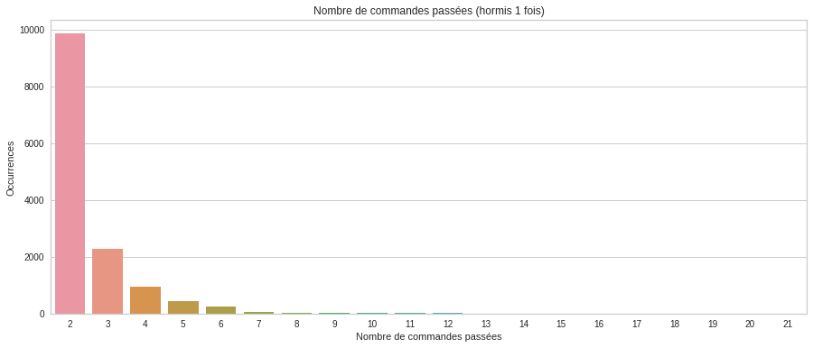

```python
plt.figure(figsize=(15, 6))
sns.countplot(x='order_item_id', data=by_items)
plt.title('Nombre de commandes passées (hormis 1 fois)')
plt.xlabel('Nombre de commandes passées')
plt.ylabel('Occurrences')
plt.show()
```

```python
by_items_max = df[
    (df["order_item_id"] > 10)]
print("Commandes contenant plus de 10 articles :", by_items_max.shape[0])
```

```
Commandes contenant plus de 10 articles : 56
```

```python
by_items_max.groupby('product_category_name')[
    'order_item_id'].count().sort_values(ascending=False).iloc[:20]
```

```
product_category_name
health_beauty            11
computers_accessories    10
garden_tools              9
housewares                7
telephony                 7
furniture_decor           6
baby                      2
watches_gifts             2
bed_bath_table            1
office_furniture          1
Name: order_item_id, dtype: int64
```

Les produits de beauté et accessoires informatiques ainsi que les outils de jardinage remontent en premières positions.

**2.2 Combien de commandes par client ?**

Nous allons créer un petit jeu de données pour identifier le nombre de commandes passées par utilisateur. Pour cela, nous allons nous appuyer sur la feature `customer_unique_id` :

```python
clients_id = df['customer_unique_id'].value_counts(
).sort_values(ascending=False)
df_cmd_nb = pd.DataFrame(clients_id)
df_cmd_nb.rename({'customer_unique_id': 'nb_cmd'}, axis=1, inplace=True)
df_cmd_nb = df_cmd_nb.rename_axis('index').reset_index()
df_cmd_nb.rename({'index': 'customer_unique_id'}, axis=1, inplace=True)
df_cmd_nb.head()
```

|  | customer_unique_id | nb_cmd |
| --- | --- | --- |
| 0 | 9a736b248f67d166d2fbb006bcb877c3 | 75 |
| 1 | 6fbc7cdadbb522125f4b27ae9dee4060 | 38 |
| 2 | f9ae226291893fda10af7965268fb7f6 | 35 |
| 3 | 569aa12b73b5f7edeaa6f2a01603e381 | 26 |
| 4 | 85963fd37bfd387aa6d915d8a1065486 | 24 |

Affichons le nombre d'achats réalisés par client :

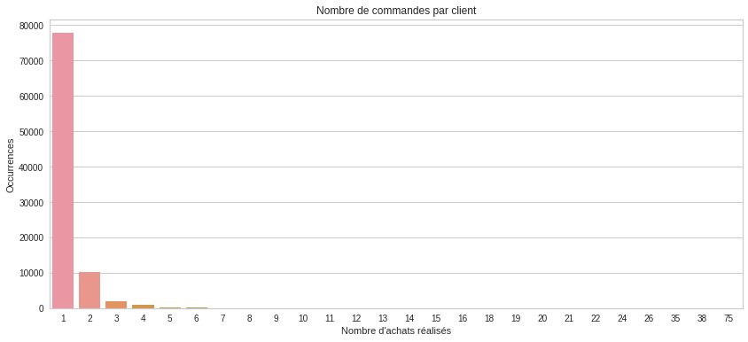

```python
plt.figure(figsize=(14, 6))
sns.countplot(x='nb_cmd', data=df_cmd_nb)
plt.title('Nombre de commandes par client')
plt.xlabel('Nombre d\'achats réalisés')
plt.ylabel('Occurrences')
plt.show()
```

L'écrasante majorité des gens achètent une seule fois. Regardons les statistiques :

```python
df_cmd_nb.nb_cmd.value_counts(normalize=True)
```

```
1    0.850
2    0.111
3    0.021
4    0.010
5    0.003
6    0.003
7    0.001
8    0.000
12   0.000
9    0.000
10   0.000
11   0.000
14   0.000
15   0.000
13   0.000
24   0.000
20   0.000
21   0.000
38   0.000
16   0.000
18   0.000
19   0.000
22   0.000
26   0.000
35   0.000
75   0.000
Name: nb_cmd, dtype: float64
```

Essayons de visualiser les clients ayant passé plus de 7 commandes :

```python
by_nb_cmd_max = df_cmd_nb[
    (df_cmd_nb["nb_cmd"] > 7)]
print("Nombre de clients ayant passé plus de 7 commandes :",
      by_nb_cmd_max.shape[0])
```

```
Nombre de clients ayant passé plus de 7 commandes : 165
```

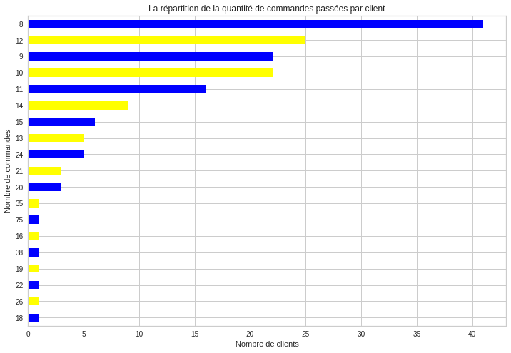

```python
plt.figure(figsize=(15, 8))
by_nb_cmd_max['nb_cmd'].value_counts().sort_values(ascending=True).plot(
    kind='barh', figsize=(12, 8), color=['blue', 'yellow'])

plt.title('La répartition de la quantité de commandes passées par client')
plt.ylabel('Nombre de commandes')
plt.xlabel('Nombre de clients')
plt.show()
```

- 40 clients ont acheté 8 fois
- Plus de 20 clients ont commandé 9, 10 et 12 fois
- 1 client a acheté 75 fois !

A présent affichons les ID des clients ayant passé le plus de commandes :

```python
df['customer_unique_id'].value_counts().sort_values(ascending=False).iloc[:20]
```

```
9a736b248f67d166d2fbb006bcb877c3    75
6fbc7cdadbb522125f4b27ae9dee4060    38
f9ae226291893fda10af7965268fb7f6    35
569aa12b73b5f7edeaa6f2a01603e381    26
85963fd37bfd387aa6d915d8a1065486    24
5419a7c9b86a43d8140e2939cd2c2f7e    24
1d2435aa3b858d45c707c9fc25e18779    24
c8460e4251689ba205045f3ea17884a1    24
db1af3fd6b23ac3873ef02619d548f9c    24
2524dcec233c3766f2c2b22f69fd65f4    22
9620623f9ea546719cb3cd99bbb879a9    21
41a3b256cc497dc952a815b848345cbc    21
4546caea018ad8c692964e3382debd19    21
c402f431464c72e27330a67f7b94d4fb    20
ed917c786a8a3e411eae87aeca27cb27    20
3806104dbbc3d14c17b091b3b8e38d59    20
24f12460aad399ba18f4ed2c2fbab65d    19
0f5ac8d5c31de21d2f25e24be15bbffb    18
69aedec762e21e5aaca6eba2e635dcfb    16
c4b224d2c784bae11ae98b6ae9f2454c    15
Name: customer_unique_id, dtype: int64
```

Les ID des clients qui se positionnent en tête du classement :

- 9a736b248f67d166d2fbb006bcb877c3 => 75 commandes
- 6fbc7cdadbb522125f4b27ae9dee4060 => 38 commandes
- f9ae226291893fda10af7965268fb7f6 => 35 commandes

**3. Catégories de produits**

Quels produits sont vendus à quelle fréquence par la société ?

```python
df.product_category_name.value_counts().index
```

```
Index(['bed_bath_table', 'health_beauty', 'sports_leisure', 'furniture_decor',
       'computers_accessories', 'housewares', 'watches_gifts', 'telephony',
       'garden_tools', 'auto', 'toys', 'cool_stuff', 'perfumery', 'baby',
       'electronics', 'stationery', 'fashion_bags_accessories', 'pet_shop',
       'office_furniture', 'luggage_accessories', 'consoles_games',
       'construction_tools_construction', 'home_appliances',
       'musical_instruments', 'small_appliances', 'home_construction',
       'books_general_interest', 'furniture_living_room', 'food',
       'home_confort', 'audio', 'drinks', 'market_place',
       'construction_tools_lights', 'kitchen_dining_laundry_garden_furniture',
       'air_conditioning', 'food_drink', 'fashion_shoes', 'books_technical',
       'industry_commerce_and_business', 'home_appliances_2',
       'fixed_telephony', 'agro_industry_and_commerce',
       'costruction_tools_garden', 'computers', 'art',
       'signaling_and_security', 'construction_tools_safety',
       'christmas_supplies', 'fashion_underwear_beach',
       'fashion_male_clothing', 'furniture_bedroom', 'costruction_tools_tools',
       'tablets_printing_image', 'small_appliances_home_oven_and_coffee',
       'cine_photo', 'dvds_blu_ray', 'books_imported', 'party_supplies',
       'fashio_female_clothing', 'furniture_mattress_and_upholstery', 'music',
       'diapers_and_hygiene', 'flowers', 'fashion_sport', 'home_comfort_2',
       'arts_and_craftmanship', 'la_cuisine', 'cds_dvds_musicals',
       'fashion_childrens_clothes', 'security_and_services'],
      dtype='object')
```

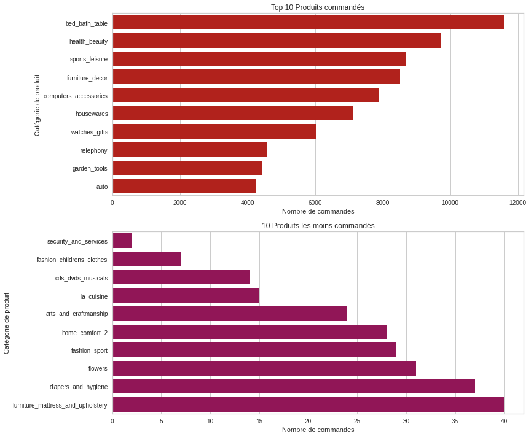

```python
top = df['product_category_name'].value_counts(
).reset_index().nlargest(10, 'product_category_name')
low = df['product_category_name'].value_counts(
).reset_index().nsmallest(10, 'product_category_name')

plt.figure(figsize=(12, 12))
red_color = sns.color_palette()[3]
green_color = sns.color_palette()[2]

plt.subplot(211)
sns.barplot(data=top, x='product_category_name', y='index', color=green_color)
plt.title('Top 10 Produits commandés')
plt.xlabel('Nombre de commandes')
plt.ylabel('Catégorie de produit')

plt.subplot(212)
sns.barplot(data=low, x='product_category_name', y='index', color=red_color)
plt.title('10 Produits les moins commandés')
plt.xlabel('Nombre de commandes')
plt.ylabel('Catégorie de produit')
plt.show()
```

Vérifions également comment sont répartis les avis clients en fonction de la catégorie du produit :

```python
round(pd.crosstab(df['product_category_name'],
      df['review_score'], normalize='index') * 100, 2)[:12]
```

| review_score product_category_name | 1 | 2 | 3 | 4 | 5 |
| --- | --- | --- | --- | --- | --- |
| agro_industry_and_commerce | 8.540 | 2.850 | 5.690 | 23.170 | 59.760 |
| air_conditioning | 12.460 | 2.770 | 9.000 | 18.690 | 57.090 |
| art | 11.220 | 3.410 | 9.270 | 19.020 | 57.070 |
| arts_and_craftmanship | 12.500 | 0.000 | 12.500 | 12.500 | 62.500 |
| audio | 16.270 | 5.070 | 9.870 | 15.470 | 53.330 |
| auto | 10.530 | 3.410 | 7.630 | 21.220 | 57.210 |
| baby | 11.580 | 3.400 | 8.380 | 19.150 | 57.490 |
| bed_bath_table | 13.910 | 4.730 | 9.820 | 19.040 | 52.490 |
| books_general_interest | 5.700 | 1.290 | 3.860 | 15.440 | 73.710 |
| books_imported | 6.780 | 1.690 | 3.390 | 8.470 | 79.660 |
| books_technical | 7.550 | 2.640 | 3.770 | 14.720 | 71.320 |
| cds_dvds_musicals | 0.000 | 0.000 | 7.140 | 21.430 | 71.430 |

La majorité des avis sont positifs : entre 52.4% et 79.6%. La catégorie `cds_dvds_musicals` n'a pas de mauvaises notes. Les catégories suivantes ont le plus de mauvaises autres : `audio`, `arts_and_craftmanship` et `bed_bath_table`.

**4. Types de paiement**

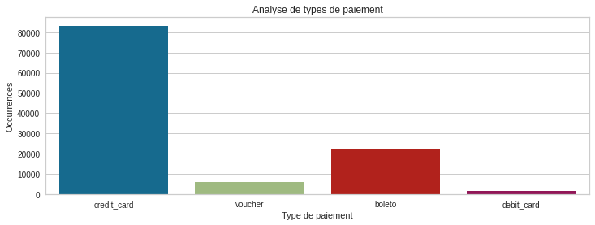

```python
plt.figure(figsize=(12, 4))
sns.countplot(x='payment_type', data=df)
plt.title('Analyse de types de paiement')
plt.xlabel('Type de paiement')
plt.ylabel('Occurrences')
plt.show()
```

Le moyen de paiement préfére des clients est de loin la carte de crédit.

**5. Localisation**

Ci-dessous le top des 15 villes où les commandes sont réalisées le plus souvent :

```python
df['customer_city'].value_counts().sort_values(ascending=False).iloc[:15]
```

```
sao paulo                17792
rio de janeiro            7760
belo horizonte            3124
brasilia                  2369
curitiba                  1766
campinas                  1674
porto alegre              1588
salvador                  1422
guarulhos                 1333
sao bernardo do campo     1073
niteroi                   1018
santo andre                884
osasco                     858
santos                     820
goiania                    784
Name: customer_city, dtype: int64
```

**6. Temps de commande**

```python
df.select_dtypes("datetime").columns
```

```
Index(['order_purchase_timestamp', 'order_approved_at',
       'order_delivered_carrier_date', 'order_delivered_customer_date',
       'order_estimated_delivery_date', 'shipping_limit_date'],
      dtype='object')
```

Examinons la répartition des commandes passées à l'échelle de l'année :

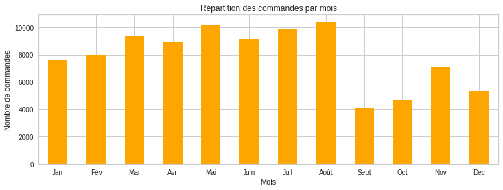

```python
df.groupby(df['order_purchase_timestamp'].dt.month)\
    .agg({"order_id": "nunique"})\
    .plot(figsize=(12, 4), kind="bar", color=['orange', 'yellow'],
          title="Répartition des commandes par mois",
          ylabel="Nombre de commandes",
          xlabel="Mois",
          legend=False)
plt.xticks(np.arange(0, 12), ['Jan', 'Fév', 'Mar', 'Avr', 'Mai', 'Juin', 'Juil', 'Août', 'Sept', 'Oct', 'Nov', 'Dec'],
           rotation='horizontal')
plt.show()
```

**7. Corrélations**

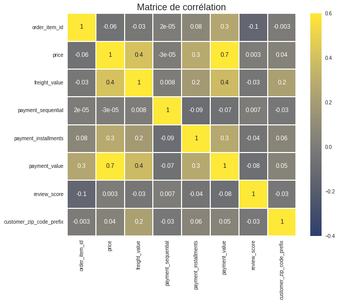

```python
plt.figure(figsize=(10, 8))
sns.heatmap(df.corr(), annot=True, fmt='.1g', linewidth=2,
            vmin=-0.4, vmax=0.6, center=0, cmap='cividis')
plt.title('Matrice de corrélation', size=18)
plt.show()
```

Nous constatons des corrélations assez évidentes parmi les features liées au prix :

- `price` fortement corrélé au `payment_value` (prix total lié à la valeur du produit acquis)
- `price` / `payment_value` également corrélé au `payment_installments` (prix total lié à l'échelonnage de paiement)
- `price` / `payment_value` également corrélé au `freight_value` (prix du produit lié au prix du transport de la cargaison)

```python
# Sauvegarde du fichier
import joblib
joblib.dump(df, 'df_suite_eda')
```

```
['df_suite_eda']
```